**1.1 Unit Conversions**

(references 1.1, 1.2)

**Prefix Multipliers**

> 10<sup>18</sup> exa E

> 10<sup>15</sup> peta P

> 10<sup>12</sup> tera T

> 10<sup>9</sup> giga G

> 10<sup>6</sup> mega M

> 10<sup>3</sup> kilo k

> 10<sup>2</sup> hecto h

> 10 deka da

> 10<sup>-1</sup> deci d

> 10<sup>-2</sup> centi c

> 10<sup>-3</sup> milli m

> 10<sup>-6</sup> micro μ

> 10<sup>-9</sup> nano n

> 10<sup>-12</sup> pico p

> 10<sup>-15</sup> femto f

10<sup>-18</sup> atto a

> *Multiply by To Obtain*

**(Common FTE conversions in boldface)**

**Angles** circles 1 circumferences

circles 12 signs

circles 21,600 minutes

circles 2π radians

circles 360 degrees

degrees .01111 quadrants

degrees 3600 seconds

degrees 60 minutes

mils (Army) .05625 degrees

mils (Navy) .05729 degrees

quadrants 90 degrees

> radians 57.2958 degrees

> revolutions 360 degrees

> sphere 4π steradians #

> #solid angle measurement

**Angular** rev/min<sup>2</sup> 0.001745 rad/sec<sup>2</sup>

**Acceleration**

**Velocity rads/sec 0.1592 rev/sec (cycles/sec)**

rads/sec 9.549 rpm

**rad/sec 57.296 deg/sec**

rpm 0.01667 rev/sec

> *Multiply by To Obtain*

**Area** acres 43,560 ft<sup>2</sup>

> ares 100 m<sup>2</sup>

barn 10<sup>-28</sup> m<sup>2</sup>

> centares 1 m<sup>2</sup>

> circular mils 7.854 x 10<sup>-7</sup> in<sup>2</sup>

> cm<sup>2</sup> 100 mm<sup>2</sup>

> **ft<sup>2</sup> 144 in<sup>2</sup>**

> **ft<sup>2</sup> 0.09290304 m<sup>2</sup>**

> in<sup>2</sup> 6.452 cm<sup>2</sup>

> in<sup>2</sup> 10<sup>6</sup> mils<sup>2</sup>

> m<sup>2</sup> 10.76 ft<sup>2</sup>

section 2,589,988.1 m<sup>2</sup>

st. mile<sup>2</sup> 2.590 km<sup>2</sup>

township 93,239,572 m<sup>2</sup>

yd<sup>2</sup> 9 ft<sup>2</sup>

yd<sup>2</sup> 0.8361 m<sup>2</sup>

**Density** * grams/cm<sup>3</sup> 0.03613 pounds/in<sup>3</sup>

> grams/cm<sup>3</sup> 62.43 pounds/ft<sup>3</sup>

kg/m<sup>3</sup> 16.018463 pounds/ft<sup>3</sup>

> **slugs/ft<sup>3</sup> 515.4 kg/m<sup>3</sup>**

> **pounds/in<sup>3</sup> * 1728 pounds/ft<sup>3</sup>**

> * Converting between force and mass (e.g. kg force to kg mass or pound force to pound mass) uses g = 32.174 ft/sec^2

**Electrical** amperes 0.1 abamperes

**Quantities** amperes 1.0365x10<sup>-5</sup> faradays/sec

amperes 2.998x10<sup>9</sup> statamperes

> amperes.cicmil 1.973x10<sup>5</sup> amperes/cm<sup>2</sup>

> ampere-hours 3,600 coulombs

> ampere-hours 1.079x10<sup>13</sup> statcoulombs

> ampere turn/cm 1.257 gilberts/cm

> ampere turn/cm 1.257 oersteds

> coulombs 0.1 abcoulombs

> coulombs 6.243x10<sup>18</sup> electronic charges

coulombs 1.037x10<sup>-5</sup> faradays

coulombs 2.998x10<sup>9</sup> statcoulombs

faradays 26.8 apmere-hours

> farads 10-9 abfarads

> farads 10<sup>6</sup> microfarads

> farads 8.986x10<sup>11</sup> statfarads

> gausses 1 maxwells/cm<sup>2</sup>

> *Multiply by To Obtain*

**Electrical** gausses 6.452 lines/in<sup>2</sup>

**Quantities** gilberts 0.7958 ampere turns

**Cont.** henries 10<sup>9</sup> abhenries

> henries 1.113x10<sup>-12</sup> stathenries

> maxwells 1 lines

> oersteds 2.998x10<sup>10</sup> statoersteds

> ohms 10<sup>9</sup> abohms

> ohms 1.113x10<sup>12</sup> statohms

> ohm-cm 6.015x10<sup>6</sup> circ mil-ohms/ft

> volts 10<sup>8</sup> abvolts

> volts 0.003336 statvolts

**Energy** / Btu 1.055x10<sup>10</sup> ergs

**Work** Btu 1055.1 Joules (N-m)

Btu 2.9302x10<sup>-4</sup> kilowatt-hours

Btu 251.99 calories (gram)

Btu 778.03 foot-pounds

> calories 4.1868 watt-seconds

> calories 3.088 foot-pounds

> electron volt 1.519x10<sup>-22</sup> Btu

> ergs 1 dyne-centimeters

> **foot-pounds 1.3558 Joules (N-m)**

foot-pounds 3.766x10<sup>-7</sup> kilowatt-hours

foot-pounds 5.051x10<sup>-7</sup> horsepower-hours

> hp-hours 0.7457 kilowatt-hours

> hp-hours 2546.1 Btu

> Joules 0.23889 calories

> Joules 1 Newton-meters

> Joules 1 watt-seconds

> Joules 10<sup>7</sup> ergs

> **kilowatt-hours 3.6x10<sup>6</sup> Joules**

> thermies 4.1868x10<sup>6</sup> Joules

> watt-second 0.73756 foot-pounds

**Force** dynes 3.597x10<sup>-5</sup> ounces

**kilogram force 9.80665 Newtons**

> kilopond force 9.80665 Newtons

> kip 4,448.221 Newtons

> **Newtons 0.224808931 pounds**

Newtons 100,000 dynes

> *Multiply by To Obtain*

**Forc e**ounce 20 pennyweights

**Cont.** ounces (troy) 480 grains

pennyweights 24 grains

pound 12 ounces

> pounds 32.174 poundals

**pounds 4.4482216 Newtons**

> pounds 5760 grains

> quintals (long) 112 pounds

> quintals (met.) 100 kilograms

> stones 14 pounds

> tons (long) 2,240 pounds

> tons (metric)* 1.102 tons (short)

> tons (short) 2000 pounds

**Fuel** **gal 5.8 lbs (U.S. AV gas)**

**gal 7.5 lbs ( U.S. oil)**

**Liter (jet A) 0.812 kilograms**

**Liter (jet A) 1.794 pounds**

**Note: Fuel densities are temperature dependent**

**Illumination** candles 1 lumens/steradian

> candles/cm<sup>2</sup> π lamberts

> candlepower 12.566 lumens

> foot-candles 1 lumens/ft<sup>2</sup>

> foot-candles 10.764 lux

> foot-lamberts 1 lumen/ft<sup>2</sup>

> lamberts 295.72 candles/ft<sup>2</sup>

> lamberts 929.03 lumens/ft<sup>2</sup>

> lumens 0.001496 watts

> lumens/in<sup>2</sup> 1 fots

> lumens/m<sup>2</sup> 1 lux

> lux 1 meter-candles

> lux 0.0001 fots

> meter-candles 1 lumens/m<sup>2</sup>

> millilamberts 0.2957 candles/ft<sup>2</sup>

> millilamberts 0.929 foot-lamberts

> milliphots 0.929 foot-candles

> milliphots 0.929 lumens/ft<sup>2</sup>

> milliphots 10 meter-candles

> *Multiply by To Obtain*

**Length** angstroms 10<sup>-10</sup> meters

astronmcl units 1.496x10<sup>11</sup> meters

> cable lengths 120 fathoms

caliber 0.01 inches

> cubit 0.4572 meters

> fermi 10<sup>-15</sup> meters

> fathoms 6 feet

feet 12 inches

furlongs 40 rods

hands 4 inches

**inches 2.54 cm**

> **kilometers 3281 feet**

> **kilometers 0.53996 nautical miles**

> leagues (U.S.) 3 nautical miles

> light years 5.88x10<sup>12</sup> statute miles

> links (engnr’s) 12 inches

> links (srvyr’s) 7.92 inches

**meters 3.28084 feet**

**meters 39.370079 inches**

> microns 0.1<sup>6</sup> meters

> mils 0.001 inches

> **nautical miles 1.15078 statute miles**

> **nautical miles 1,852 meters**

> **nautical miles 6,076.115486 feet**

> paces 0.762 meters

> parsec 1.9163x10<sup>13</sup> statute miles

> perch 5.0292 meters

> pica (printers) 0.0042175176 meters

> point (printers) 0.0003514598 meters

> pole (=rod) 5.0292 meters

> skein 109.728 meters

> **statute miles 5,280 feet**

> **statute miles 1.609344 kilometers**

> statute miles 8 furlongs

yards 3 feet

> *Multiply by To Obtain*

**Linear** feet/sec<sup>2</sup> 1.09728 kilometers/hr/sec

**Acceleration** feet/sec<sup>2</sup> 0.3048 meters/sec<sup>2</sup>

> feet/sec<sup>2</sup> 0.6818 mph/sec

**g 32.174049 feet/sec<sup>2</sup>**

> **g 9.80665 meters/sec<sup>2</sup>**

> gals (Galileo) 0.01 meters/sec<sup>2</sup>

> knots/sec 1.6878 feet/sec<sup>2</sup>

> meters/sec<sup>2</sup> 3.6 kilometers/hr/sec

mph/sec 0.447 meters/sec<sup>2</sup>

> mph/sec 1.609 kilometers/hr/sec

**Mass*** carats *200* milligrams

> grams 0.035274 ounces

grains 6.479891x10<sup>-5</sup> kilograms

> hndrdwght long 50.80 234544 kilograms

> hndrdwght shrt 45.359237 kilograms

> **kilograms 0.06852 slugs**

kilograms 6.024x1026 atomic mass units

**kilograms 2.2046 pounds**

ounces (avd)* *28.349523125* grams

ounces (troy)* *31.1034768* grams

> pounds (mass) 1 pounds (force)

> **pounds (mass) 0.45359237 kilograms**

**pounds (mass) 0.031081 slugs**

scuples (apoth) 0.0012959782 kilograms

**slugs 32.174 pounds**

**slugs 14.594 kilograms**

> tons (long) 1016.047 kilograms

> tons (assay) 0.02916 kilograms

> tons (metric) *1000* kilograms

> tons (short) 907.1847 kilograms

> * Converting between force and mass (e.g. kg force to kg mass or pound force to pound mass) uses g = 32.174 ft/sec^2

> *Multiply by To Obtain*

**Moments** gram-cm<sup>2</sup> 0.737x10<sup>-7</sup> slug-ft<sup>2</sup>

**of** pound-ft<sup>2</sup>* 0.031081 slug-ft<sup>2</sup>

**Inertia*** slug-in<sup>2</sup> 0.0069444 slug-ft<sup>2</sup>

**slug-ft<sup>2</sup> 1.3546 kg-m<sup>2</sup>**

**slug-ft<sup>2</sup> 32.174 pound-ft<sup>2</sup>**

slug-ft<sup>2</sup> 12.00 pound-inch-sec<sup>2</sup>

> slug-ft<sup>2</sup> 192.00 ounce-inch-sec<sup>2</sup>

> * Converting between force and mass (e.g. kg force to kg mass or pound force to pound mass) uses g = 32.174 ft/sec^2

**Power** btu/min 0.01758 kilowatts

> calories(kg)/min 3087.46 foot-pounds/min ergs/sec 7.376x10<sup>-8</sup> foot-pounds/sec

> ft(lbs)/min 2.260x10-<sup>5</sup> kilowatts

> ft(lbs)/sec 0.07712 btu/min

> ft(lbs)/sec 1.356 watts

> **hp 550 ft(lb)/sec**

**hp 33,000 ft(lbs)/min**

> hp 10.69 calories (kg)/min

> hp 745.7 watts
> $$J/sec$$

> **hp (metric) 735.5 watts**

**kilowatts 1.341 horsepower**

> watts 10<sup>7</sup> ergs/sec

watts 1 Joules/sec

**Pressure** **atmospheres 14.696 pounds/in<sup>2</sup>**

> **atmospheres 29.92 inches of Hg**

> atmospheres 76 cm of Hg

> bars 1,000,000 dynes/cm<sup>2</sup>

> **bars 29.52 inches of Hg**

> **barye 0.1 Newtons/m<sup>2</sup>**

**inches of H<sub>2</sub>O 5.20237 pound/ft<sup>2</sup>**

> **inches of Hg 70.72619 pounds/ft<sup>2</sup>**

> inches of Hg 0.491154 pounds/in<sup>2</sup>

> inches of Hg 13.595 inches of H<sub>2</sub>O

**hectoPascals 1 millibars**

**millibars 0.02953 inches of Hg**

mm of Hg 0.019337 pounds/in<sup>2</sup>

> *Multiply by To Obtain*

**Pressure** mm of Hg 133.32 Newtons/m<sup>2</sup>

**Cont.** **Pascals 1 Newton/m<sup>2</sup>**

pieze 1000 Newtons/m<sup>2</sup>

**pounds/ft<sup>2</sup> 0.01414 inches of Hg**

**pounds/ft<sup>2</sup> 47.88 Newtons/m<sup>2</sup>**

**pounds/in<sup>2</sup> 2.036 inches of Hg**

pounds/in<sup>2</sup> 27.681 inches of H<sub>2</sub>O

> **pounds/in<sup>2</sup> 6894.75728 Pascal**

> torrs 133.32 Newtons/m<sup>2</sup>

**Temperature Kelvin = <sup>o</sup>*C*+273.15<sup>o</sup>**

**Rankin = <sup>o</sup>*F* + 459.67<sup>o</sup>**

<sup>o</sup>Centigrade =
$$°*F* − 32°$$
5/9

> <sup>o</sup>Fahrenheit = (9/5)<sup>o</sup>*C* + 32

**Time** days (solar) 24 hours

days (sidereal) 23.934 hours

days (solar) 1.0027 days (sidereal)

> hours 60 minutes

> minutes 60 seconds

> months (sdrl) 27d + 7hr +43min +11.47sec

> months (lunar) 29d +12hr +44min + 2.78sec

> year 365.24219879 days

**Torque** * **foot-pounds 1.3558 Newton-meters**

foot-pounds 0.1383 kilogram-meters

> ounce-inches 72.008 gram-centimeters

pound-inches 1129800 dyne-centimeters

> * Converting between force and mass (e.g. kg force to kg mass or pound force to pound mass) uses g = 32.174 ft/sec^2

**Velocity** inches/sec 0.0254 meters/sec

> **knots 1.68781 feet/sec**

**km/hr 0.621371 mph**

**km/hr 0.9113 feet/sec**

**Knots (kts) 1.15078 mph**

**Knots (kts) 1.852 km/hr**

**Knots (kts) 0.51444 meters/sec**

meters/sec 3.281 ft/sec

**meters/sec 3.6 km/hr**

**meters/sec 196,85 feet/min**

mph 1.466667 feet/sec

> *Multiply by To Obtain*

**Viscosity** centistokes 10<sup>-6</sup> m<sup>2</sup>/sec

> ft<sup>2</sup>/sec 0.0929 m<sup>2</sup>/sec

> pound sec/ ft<sup>2</sup> 47.880258 Newton secs/ m<sup>2</sup>

> poise 0.1 Newton secs/ m<sup>2</sup>

rhe 10 m<sup>2</sup>/Newton second

**Volume** acre-feet 43,560 ft<sup>3</sup>

acre-feet 1,233 m<sup>3</sup>

acre-feet 3.259x10<sup>5</sup> gals (U.S.)

barrels 31.5 gals (U.S.)

> board-feet 144 in<sup>3</sup>

bushels 1.244 ft<sup>3</sup>

bushels 32 quarts (dry)

bushels 4 pecks

> cm<sup>3</sup> 0.001 liters

> cm<sup>3</sup> 0.03381 fluid ounces

cm<sup>3</sup> 0.06102 in<sup>3</sup>

cord-feet 4x4x1 ft<sup>3</sup>

cords 128 ft<sup>3</sup>

cups 0.5 pints (liquid)

> dram (fluid) 3.69669x10<sup>-6</sup> m<sup>3</sup>

> **ft<sup>3</sup> 0.0283167 m<sup>3</sup>**

> ft<sup>3</sup> 1728 in<sup>3</sup>

> ft<sup>3</sup> 28.32 liters

> **ft<sup>3</sup> 7.481 gals (U.S.)**

> **gals (Imperial) 1.2009 gals (U.S.)**

> gals (Imperial) 277.42 in<sup>3</sup>

> gals (U.K.) 4546.1 cm<sup>3</sup>

> **gals (U.S.) 231 in<sup>3</sup>**

> **gals (U.S.) 0.003785 m<sup>3</sup>**

> **gals (U.S.) 3.785 liters**

> gals (U.S.) 4 quarts (liquid)

> gals (U.S.) 0.0238095 barrels (U.S.)

> gils 7.219 in<sup>3</sup>

> hogshead 2 barrels

> in<sup>3</sup> 16.39 cm<sup>3</sup>

> liters 0.02838 bushels

> liters 0.9081 quarts (dry)

> liters 1.057 quarts (liquid)

> liters 1000 cm<sup>3</sup>

liters 61.03 in<sup>3</sup>

m<sup>3</sup> 1.308 yd<sup>3</sup>

> *Multiply by To Obtain*

**Volume** m<sup>3</sup> 1000 liters

**Cont.** m<sup>3</sup> 264.2 gals (U.S.)

> **m<sup>3</sup> 35.314667 ft<sup>3</sup>**

> mil-feet (circ.) 0.0001545 cm<sup>3</sup>

> ounces (U.K.) 28.413 cm<sup>3</sup>

ounces (U.S.) 29.574 cm<sup>3</sup>

pecks 8 quarts (dry)

> pecks 8.81 liters

perches 0.7008 m<sup>3</sup>

perches 24.75 ft<sup>3</sup>

> pints (dry) 33.60 in<sup>3</sup>

> pints (liquid) 28.88 in<sup>3</sup>

> quarts (dry) 1.164 quarts (liquid)

> quarts 2 pints

> register tons 100 ft<sup>3</sup>

> shipping ton (U.S.) 40 ft<sup>3</sup>

> shipping ton (Br.) 42 ft<sup>3</sup>

> steres 1000 liters

> tablespoons 0.0625 cups

> teaspoons 0.3333 tablespoons

**1.2 Greek Alphabet**

> Α α Alpha

> Β β Beta

> Γ γ Gamma

> ∆ δ Delta

> Ε ε Epsilon

> Ζ ζ Zeta

> Η η Eta

> Θ θ Theta

> Ι ι Iota

> Κ κ Kappa

> Λ λ Lambda

> Μ μ Mu

> Ν ν Nu

> Ξ ξ Xi

> Ο ο Omicron

> Π π Pi

> p ρ Rho

> Σ σ Sigma

> Τ τ Tau

> Υ υ Upsilon

> Φ φ Phi

> Χ χ Chi

> Ψ ψ Psi

> Ω ω Omega

**1.3 Greek Symbols Used for Aircraft**

α angle of attack (degrees or radians)

α<sub>τ</sub> tail angle of attack

β angle of sideslip (degrees)

γ flight path angle relative to horizontal

γ specific heat ratio (1.4 for air)

δ relative pressure ratio (*P<sub>a</sub>*/*P<sub>o</sub>*)

δ<sub>a</sub> aileron deflection angle

δ<sub>r</sub> rudder deflection angle

δ<sub>e</sub> elevator deflection angle

ε downwash angle at tail (degrees)

ζ damping ratio

η efficiency

θ body axis/pitch angle

θ relative temperature ratio, *T<sub>a</sub>*/*T<sub>o</sub>*

ι angle of incidence

ι*<sub>F</sub>* thrust angle of incidence

ι*<sub>T</sub>* horizontal tail angle of incidence

λ pressure lag constant

Λ wing sweep angle

μ coefficient of absolute viscosity = ρν

μ Mach cone angle

π nondimensional parameter

ρ density

ρ*<sub>a</sub>* ambient air density

ρ<sub>*o*</sub> standard atmospheric density (slugs/ft3 )

σ air density ratio (ρ*<sub>α</sub> /*ρ*<sub>ο</sub>*)

σ<sub>cr</sub> critical density

τ shear stress (pounds per square inch) psi

τ<sub>R</sub> Roll Mode Time Constant (sec)

φ bank angle (degrees)

ψ aircraft heading (degrees)

ω frequency

ω rotational velocity (radians per second)

ω<sub>*d*</sub> damped natural frequency

ω*<sub>n</sub>* natural undamped frequency

**1.4 Common Subscripts**

> *a* aileron

> *a* ambient

> alt at test altitude

> avg average

> *c* calibrated

> *e* elevator

> *e* equivalent

> *E* endurance leg of mission

> *F* final

> *I* initial

> *i* inbound leg of mission

> *i* indicated

> *ic* instrument corrected

> *l* subscript for coefficient of rolling moment

> *m* mission conditions

> *m* pitching moment

> *n* yawing moment

> *O* outbound leg of mission

> *o* sea-level standard day

> *o* sea level

> *r* reserve leg of mission

> *r* rudder

> *S* standard day

> *s* standard day at altitude

> *SL* sea level

> *T* True

> *t* test day

**1.5 Common Abbreviations**

a lift curve slope

a linear acceleration (ft/sec<sup>2</sup> or m/sec<sup>2</sup>)

a speed of sound

A/A air-to-air

a/c aircraft

AAA anti aircraft artillery

AC aerodynamic center

ac alternating current

ACM air combat maneuvering

A/D analog to digital

ADC air data computer

ADC analog-to-digital converter

ADF automatic direction finder

ADI attitude direction indicator

AFMC Air Force Materiel Command

AFOTEC Air Force Operational Test and Evaluation Center

A/G air-to-ground

AGL above ground level

AHRS attitude heading reference system

AM amplitude modulation

AOA angle of attack

AOED age of ephemeris data

APU auxiliary power unit

AR air refuel (mode of flight)

*AR* aspect ratio = b<sup>2</sup> / S

ARDP advanced radar data processor

ARSP advanced radar signal processor

ASPJ airborne self protection jammer

ATC air traffic control

avg average

ax longitudinal acceleration

ay lateral acceleration

AZ azimuth

b span of wing (feet)

B/N bombadier/navigator

bbl barrel

*BHP* brake horsepower

BICOMS bistatic coherent measurement system

BID bus interface device

BIT built-in test

*BSFC* brake specific fuel consumption

Btu British thermal unit

BW bandwidth

<sup>o</sup>*C* degrees centigrade...see *T*

c brake specific fuel consumption (BSFC)

c speed of light in a vacuum

(186,282 miles/sec = 299,792,500
$$m/s$$
)

c mean aerodynamic chord (MAC) of a wing

C/A coarse acquisition

C/N<sub>o</sub> carrier to noise ratio

CADC central air data computer

CARD cost analysis requirement document

*C<sub>D</sub>* coefficient of drag

*C<sub>D</sub>* <sub>i</sub> induced drag coefficient

*C<sub>D</sub>* <sub>o</sub> zero lift drag coefficient

(also parasitic drag coefficient for symmetric wing)

CDI course deviation indicator

CDMA code division multiplex access

CDR critical design review

CDRL contracts data requirement list

CDU control display unit

CEA circular error average

CEP circular error probable

*C<sub>f</sub>* coefficient of friction

CFE contractor furnished equipment

CFT conformal fuel tank

*cg* center of gravity (normally in % MAC)

C<sub>H</sub> hinge moment coefficient

cine cinetheodolite

*C<sub>l</sub>* rolling moment coefficient, airfoil section lift co efficient

*C<sub>L</sub>* lift coefficient

CLHQ closed loop handling qualities

*C<sub>lp</sub>* roll damping coefficient

*C<sub>lr</sub>* roll moment due to yaw rate coefficient

*C<sub>m</sub>* pitching moment coefficient

*C<sub>M</sub>* moment coefficient

cm centimeters

cos cosine

cot cotangent

*C<sub>lβ</sub>* (dihedral) rolling moment due to sideslip

*C<sub>l</sub>*<sub>δa</sub> aileron power coefficient

*Cm<sub>q</sub>* pitch damping coefficient

*Cm<sub>α</sub>* longitudinal static stability coefficient

*Cm<sub>δe</sub>* elevator power coefficient

*Cn* yawing moment coefficient

*Cn<sub>r</sub>* yaw damping coefficient

cnst constant

*Cn<sub>β</sub>* directional stability coefficient

*Cn<sub>δa</sub>* adverse yaw coefficient

*Cn<sub>δr</sub>* rudder power coefficient

COTS commercial, off–the-shelf

CP center of pressure

*C<sub>P</sub>* propeller power coefficient

CPU central processing unit

c<sub>r</sub> wing root chord

CRM crew resource management

c<sub>t</sub> wing tip chord

CTF combined test force

CY calendar year

*C<sub>Y</sub>* side force coefficient

*CY<sub>β</sub>* side force due to sideslip coefficient

*CY<sub>δr</sub>* side force due to rudder coefficient

D diameter

D drag

D/A digital/analog

DAC digital to analog converter

DAPS data acquisition and processing system

DARPA Defense Advanced Research Projects Agency

db decibel

DC direct current

deg degrees

DG directional gyro

DGPS differential GPS

DMA Defense Mapping Agency

DME distance measuring equipment

DoD Department of Defense

DOP dilution of precision

DSN defense switched network

DT development test

DTC data transfer cartridge

DTIC Defense Technical Information Center

*e* Oswald efficiency factor

e natural mathematical constant = 2.718281828459

E energy

E lift-to-drag ratio (C<sub>L</sub>/C<sub>D</sub>, L/D)

EAS equivalent airspeed

EC electronic combat

ECCM electronic counter countermeasures

ECM electronic countermeasures

ECP engineering change proposal

ECS environmental control system

EGT exhaust gas temperature

EL elevation

ELINT electronic intelligence

ELV expendable launch vehicle

EM electromagnetic

*E*<sub>max</sub> maximum lift-to-drag ratio

EMC electromagnetic compatibility

EMI electromagnetic interference

EMP electromagnetic pulse

EO electro optical

EOM equations of motion

EPR engine pressure ratio

EPROM electrically programmable read only memory

*Es* specific energy

ESA European Space Agency

ESD Electronic Systems Division

*ESHP* equivalent shaft horsepower

ETA estimate time of arrival

ETE estimate time en-route

EW early warning

EW electronic warfare

<sup>o</sup>*F* degrees Fahrenheit

*f* frequency...hertz (originally cycles per second)

F.S. fuselage station

*F<sub>a</sub>* aileron force

FAA Federal Aviation Administration

FAR Federal Aviation Regulation

FCF functional check flight

FDC flight data computer

*F<sub>e</sub>* elevator force

*F<sub>ex</sub>* excess thrust

*F<sub>g</sub>* gross thrust

FL flight level

Flip flight information publication

FLIR forward-looking infra red

FM frequency modulation

FMC fully mission capable

FMS flight management system

FMS foreign military sales

*Fn* net thrust

*Fn*/δ corrected thrust parameter

FOM figure of merit

FOT&E follow-on test & evaluation

FOUO for official use only

FOV field of view

fpm feet per minute

fps feet per second

FQT formal qualification test

*Fr* rudder force

FRD functional requirements document

FRL fuselage reference line

FRL force, rudder, left

FRR force, rudder, right

FRR flight readiness review

FSD full scale development

FSI full scale integration

ft feet

ft-lb English unit of work...foot-pound...

fwd forward

FY fiscal year

*g* acceleration due to gravity at altitude

*G* gravitational constant = 6.6732x10<sup>-11</sup>
$$N m^2^/kg^2^$$

GAO Government Accounting Office

GCA ground control approach

GCI ground controlled intercept

GDOP geometric dilution of precision

GMT Greenwich mean time

*g<sub>o</sub>* standard acceleration due to gravity

GPS global positioning system

GS ground speed

GSI glide slope indicator

*h* % MAC

*H* altitude

HARM high-speed anti-radiation missile

*H<sub>c</sub>* calibrated altitude

(assumed to be pressure altitude in flight test)

*H<sub>D</sub>* density altitude

HDDR high density digital recorder

HDOP horizontal dilution of precision

HF high frequency

*Hg* mercury

*H<sub>i</sub>* indicated altitude

*h<sub>m</sub>* stick-fixed maneuver point (%MAC)

*h<sub>'m</sub>* stick-free maneuver point (%MAC)

*h<sub>n</sub>* stick-fixed neutral point (%MAC)

*h<sub>'n</sub>* stick-free neutral point (%MAC)

hp horsepower

hr hour

hrs hours

HSI horizontal situation indicator

HUD head-up display

HV host vehicle

*Hz* hertz

I/O input/output

IAS indicated airspeed

IAW in accordance with

ICAO International Civilian Aviation Organization

ICU interface computer unit

ICBM intercontinental ballistic missile

IFF identification friend or foe

IFR instrument flight rules

ILS instrument landing system

IMC instrument meteorological conditions

IMN indicated Mach number

IMU inertial measuring unit

in inch

INS inertial navigation system

INU inertial navigation unit

IOC initial operational capability

IOT&E initial operational test & evaluation

IUGG International Union of Geodesy and Geographics

*I<sub>x</sub>, I<sub>x</sub>, I<sub>z</sub>* moments of inertia

*I<sub>xy</sub>, I<sub>xz</sub>, I<sub>yz</sub>* products of inertia

*J* joules energy, (Newton-Meter)

*J* propeller advance ratio

J&S jamming and spoofing

JCS Joint Chiefs of Staff

*K* Kelvin (absolute temperature)

K temperature probe recovery factor

*K, k*1 constants

KCAS knots calibrated airspeed

KEAS knots equivalent airspeed

kg kilogram, metric unit of mass

KIAS knots indicated airspeed

KISS keep it simple, stupid

km kilometer

KTAS knots true airspeed

kt knots

*L* Lift (lbs)

*l* length

*L* rolling moment

L/D Lift-to-drag ratio

LANTIRN low altitude navigation and targeting IR for night

lat lateral

lb pound

lb<sub>f</sub> English unit of force, often just lb (pound)

lb<sub>m</sub> English unit of mass, often just lb (slug)

LCC life cycle cost

LCD liquid crystal display

LED light emitting diode

LLH latitude, longitude, height

ln natural log, log to the base e

LO low observables

Log common log, to the base 10

LOS line of sight

*l*<sub>t</sub> distance from *cg* to tail's aerodynamic cent

L<sub>δa</sub> rolling moment due to aileron deflection

*M* moment (ft-lbs)

*M* Mach number

m mass

m meter (length)

*M* pitching moment

MAG magnetic

MAP manifold pressure

mb millibar

MCA minimum crossing altitude

*M<sub>cr</sub>* critical Mach number

*M<sub>d</sub>* drag divergence Mach number

M<sub>ac</sub> mean aerodynamic cord

M<sub>GC</sub> mean geometric chord

MHz megahertz

mHZ millihertz

*M<sub>ic</sub>* instrument-corrected Mach number

MilSpec military specification

MIL-STD military standard (publication)

min minute (time)

Mm millimeters

MOA memorandum of agreement

MOE measure of effectiveness

MOP measures of performance

MOU memorandum of understanding

MP manifold pressure

MSL mean sea level

MTBF mean time between failures

MTTR mean time to repair

MX maintenance

N newton (force)

N rotational speed (RPM)

*n* load factor (g's)

N yawing moment

*N*<sub>1</sub> low pressure compressor speed

*N*<sub>2</sub> high pressure compressor speed

NACA National Advisory Committee for Aeronautics

NADC Naval Air Development Center

NASA National Aeronautics and Space Administration

NAV navigation

NED North, East, Down

NM, nm nautical mile (6080 feet)

NOE nap-of-the-earth

NOFORN not releasable to foreign nationals

NOTAM notice to airmen

NRC National Research Council (Canada)

NWC Naval Weapons Center

*N<sub>x</sub>* longitudinal load factor (g's)

N<sub>y</sub> lateral load factor (g's)

*N<sub>z</sub>* normal load factor (g's)

OAT outside air temperature

OAT on aircraft test

OEI One engine inoperative

OPR Office of Primary Responsibility

OSD Office of the Secretary of Defense

OT&E operational test & evaluation

p aircraft roll rate (degrees/sec)

P pressure (N/m<sup>2</sup> ,pounds per square inch)

P<sub>a</sub> ambient pressure

PCM pulse code modulation

P-code precision code

PD pulse Doppler

PDM pulse duration modulation

PGM precision guided munitions

PIO pilot induced oscillations

P<sub>iw</sub> total thrust horsepower required

Pk probability of kill

PLF power for level flight

P<sub>o</sub> standard atmospheric pressure (2116.22 lb/ft<sup>2</sup> )

POC point of contact

P<sub>p</sub> pitot pressure

ppm parts per million

Prop propeller

P<sub>s</sub> static pressure

PS pulse search

psf pounds per square foot

psi pounds per square inch

P<sub>T</sub> total pressure

PW pulse width

*Q* or *q* dynamic pressure = 0.5ρ*V* <sup>2</sup>

q aircraft pitch rate

Q engine torque

q<sub>c</sub> impact pressure (*P<sub>t</sub>* − *P<sub>a</sub>*)

<sup>o</sup>*R* degrees Rankine = <sup>o</sup>*F* + 459.67

R perfect gas constant = 8314.34
$$J/kmol K$$

r aircraft yaw rate (degrees/sec)

R earth radius

R range

R&D research and development

R&M reliability and maintainability

R/C rate of climb

rad radians

Radar radio detection and ranging

RAF resultant aerodynamic force

RAM radar absorbing material

RAT ram air turbine

RCS radar cross section

Re Reynolds number (dimensionless)

REP range error probable

RF range factor

RLG ring laser gyro

rms root mean square

RNG range

ROC rate of climb

ROC required obstacle clearance

RPM revolutions per minute (a.k.a. N)

R/T receiver/transmitter

RTO Rejected/refused takeoff

RTO responsible test organization

S wing area (ft<sup>2</sup> or m<sup>2</sup>)

S<sub>a</sub> horizontal distance between liftoff and specified height or between specified height and touch down.

SA selective availability

SA situational awareness

SE specific endurance

sec seconds (time or angle)

SFC specific fuel consumption

S<sub>g</sub> ground roll distance

SHP shaft horsepower

SI international system of units

SIGINT signal intelligence

sin sine

SL sea level

SLAM standoff land attack missile

SLR side-looking radar

S/N serial number

S/N signal -to-noise ratio

SOF special operations forces

SOW stand-off weapon

SR specific range

SRB safety review board

S<sub>T</sub> tail area

std standard

S<sub>T</sub> total takeoff or landing distance (S<sub>a</sub> + S<sub>g</sub>)

STOL short takeoff and landing

STOVL short takeoff and vertical landing

T period of oscillation

T temperature

t thickness

T, t time (sec)

t/c thickness-to-chord ratio

T<sub>a</sub> ambient temperature

TACAN tactical air navigation

tan tangent

T<sub>as</sub> standard temperature at altitude

TAS true airspeed

TBD to be determined

TD touchdown

TED trailing edge down

TEL trailing edge left

TEMP test and evaluation master plan

TER trailing edge right

TEU trailing edge up

TF terrain following

THP Thrust Horsepower

THP<sub>alt</sub> horsepower available at altitude

THP<sub>max</sub> maximum horsepower available

THP<sub>min</sub> minimum horsepower required

THP<sub>SL</sub> horsepower required at sea level

TIT turbine inlet temperature

TM telemetry

TMN true Mach number

T/O takeoff

T<sub>o</sub> standard sea level temperature (59.0 <sup>o</sup>F, 15 <sup>o</sup>C)

TO technical order

TRB technical review board

TRD technical requirements document

TRP technical resources plan

TSFC thrust specific fuel consumption

TSPI time, space, position information

T<sub>t</sub> total temperature

TV television

T/W thrust to weight ratio

TWT track while scan

TWT traveling wave tube

u velocity along aircraft's x-axis

UAV uninhabited aerial vehicle

UHF ultra high frequency

UPT undergraduate pilot training

USA US Army

USAF US Air Force

USCG US Coast Guard

USMC US Marine Corps

USN US Navy

UT universal time

UV ultraviolet

v velocity along aircraft's lateral axis

V<sub>H</sub> horizontal tail volume coefficient

V<sub>V</sub> vertical tail volume coefficient

V<sub>1</sub> takeoff decision speed

V<sub>2</sub> takeoff safety speed

V<sub>A</sub> design maneuvering speed

VAC volts AC

V<sub>b</sub> buffet airspeed

V<sub>B</sub> design speed for max gust intensity

V<sub>br</sub> velocity for best range

V<sub>c</sub> calibrated airspeed

V<sub>D</sub> design diving speed

VDC volts DC

VDOP vertical dilution of precision

V<sub>e</sub> equivalent velocity

V<sub>FE</sub> maximum flap extended speed

V<sub>FR</sub> visual flight rules

V<sub>g</sub> ground speed

VHF very high frequency

V<sub>i</sub> indicated airspeed

V<sub>ic</sub> indicated airspeed corrected for instrument error

V<sub>iw</sub> velocity at sea level std day and std weight

VLE max speed with landing gear extended

V<sub>LO</sub> max speed while operating landing gear

V<sub>LOF</sub> lift off speed

VLSIC very large scale integrated circuit

V<sub>mc</sub> minimum directional control speed

VMC visual meteorological conditions

V<sub>mca</sub> minimum directional control speed in the air

V<sub>mcg</sub> minimum directional control speed on the ground

V<sub>mo</sub>/M<sub>mo</sub> maximum operating limit speed

V<sub>mu</sub> minimum unstick speed

V<sub>NE</sub> never exceed velocity

V<sub>no</sub> max structural cruising speed

V<sub>opt</sub> optimum velocity for endurance flight

VOR VHF omni-directional range

VORTAC VHF omni-directional range Tactical Air Navi gation

V<sub>Pmin</sub> velocity for minimum power

V<sub>Pmin,SL</sub> velocity for minimum power at sea level

V<sub>R</sub> rotation speed

V<sub>S</sub> stall speed

V<sub>S0</sub> stall speed in landing configuration

V<sub>S1</sub> stall speed in some defined configuration

VSTOL vertical/short takeoff and landing

V<sub>T</sub> true airspeed

VTOL vertical takeoff & landing

VVI vertical velocity indicator

V<sub>W</sub> wind velocity

V<sub>X</sub> speed for best angle of climb

V<sub>Y</sub> speed for best rate of climb

W weight

w component of velocity along aircraft's Z-axis

WDL weapon data link

W/δ weight-to-pressure ratio

W<sub>f</sub> fuel weight

WGS-84 World Geodetic System, 1984

WI watch item

WOD word of day

WOW weight on wheels

WPT waypoint

wrt with respect to

, corrected fuel flow parameter

W/S wing loading

W<sub>f</sub> fuel flow (lb/hr)

x aircraft longitudinal axis,

a line running through the nose & tail

X<sub>ac</sub> distance from leading edge to aerodynamic cen ter

Xlink cross link

y aircraft lateral axis, a line running the wingtips

Y force along y-axis

Y-code encrypted P-code

z aircraft vertical or yaw axis,

a line perpendicular to the longitudinal and lat eral axes

∆*H<sub>ic</sub>* altimeter instrument correction

∆*H<sub>pc</sub>* altimeter position error correction

∆P<sub>p</sub> pitot pressure error

∆P<sub>s</sub> static pressure error

∆V<sub>c</sub> scale attitude correction to airspeed

∆V<sub>ic</sub> instrument correction to airspeed indicator

∆V<sub>pc</sub> correction for airspeed position error

∞ infinity, or freestream conditions

**1.6 Sign Conventions** (reference 1.8)

**Editor’s note** There is near unanimous agreement on most sign conventions except for pilot inputs and control surface deflections. Although individual organizations generally are consistent in-house, confusion often arises when trying to mathematically translate inputs & deflections from one organization to another. This section documents the generally accepted “body axes” sign conventions then discusses the rationale for several viewpoints addressing the “inputs & deflections” debate. Below is the SFTE sign convention.

**Wind Axes Sign Convention**

Winds are listed according to the direction they are coming from. Airports refer winds to magnetic North while winds at altitude are typically referred to true North. Headwind is true airspeed minus ground speed. (*V<sub>w</sub>=V<sub>T</sub>-V<sub>g</sub>*).

**Body Axes Sign Convention**

The generally accepted body axes sign convention is based on the establishment of a three-dimensional axis system with the following properties:

1. It is right-handed orthogonal

2. Its origin is at the vehicle's reference center of gravity (defined by builder).

3. The axis system moves with the airframe.

[figure not shown]

Translational displacements, rates, accelerations, & forces are positive along the positive body axes directions. In spite of the simplicity of this logic, it is important to recognize that lift and normal load factor are positive in the *negative z* direction and the drag is positive in the *negative x* direction.

Angular displacements, rates, accelerations & moments, are positive according to the “right hand rule” (a clockwise rotation while looking in the direction of the positive axis) as shown in the figure.

The body axes, forces & translations along them, and moments & rotations about them are shown with arrows indicating the positive direction.

Angular displacements, rates, accelerations & moments, are positive according to the “right hand rule” (a clockwise rotation while looking in the direction of the positive axis) as shown in the figure.

The body axes, forces & translations along them, and moments & rotations about them are shown with arrows indicating the positive direction.

[figure not shown]

Angle of attack is positive clockwise from the projection of the velocity vector on the *xz* plane to the reference *x* body axis. The angle of sideslip is positive clockwise from the *xz* plane to the velocity vector (wind in the pilot’s right ear).

Aircraft *true* heading is the angle between *true* North and the projection of the x-body axis onto the horizontal plane. Mag. heading refers to mag North

The velocity vector is measured relative to the air mass while the flightpath is measured relative to the ground. They are equivalent only when winds are zero.

Flightpath heading angle (ground track heading) *σ<sub>g</sub>*, is the horizontal angle between true North and the projection of the flightpath on the horizontal plane. Positive rotation is from north to east.

€

Flightpath elevation angle; *γ*, is the vertical angle between the flightpath and the horizontal plane. Positive rotation is up. During a descent, this parameter is commonly known as glide path angle.

Flightpath bank angle; *μ*, is the angle between the plane formed by the velocity vector and the lift vector and the vertical plane containing the velocity vector. Positive rotation is clockwise about the velocity vector, looking forward.

Fuselage reference station (FRS), Water line (WL), and Buttock line (BL) are reference coordinates established by the design group.

| **Summary of Generally Accepted Body Axes Sign Convention** |  |  |
| --- | --- | --- |
| **Parameter Name** | **Symbol** | **Positive Direction** |
| Translational Measurements |  |  |
| Longitudinal axis | x | from ref *cg* towards nose |
| Lateral axis | y | from reference *cg* towards right wing tip |
| Vertical axis | z | from reference *cg* towards vehicle bottom (body axis) |
| Longitudinal velocity | u | along +x axis |
| Lateral velocity | v | along +y axis |
| Vertical velocity | w | along +z axis |
| Long. acceleration | a<sub>x</sub> | along + x axis |
| Lateral acceleration | a<sub>y</sub> | along +y axis |
| Vertical acceleration | a<sub>z</sub> | along +z axis |
| Longitudinal load factor | N<sub>x</sub> | along +x axis |
| Lateral load factor | N<sub>y</sub> | along +y-axis |
| Normal load factor | N<sub>z</sub> | along –z axis |
| Longitudinal force | F<sub>x</sub> | along the +x axis |
| Lateral force | F<sub>y</sub> | along the +y axis |
| Normal force | F<sub>z</sub> | along the + z axis |
| Drag force | D | along the –x axis |
| Side force | Y | along the + y axis |
| Lift Force | L | along the –z axis |

| **Summary of Generally Accepted Body Axes Sign Convention** |  |  |
| --- | --- | --- |
| **Parameter Name** | **Symbol** | **Positive Direction** |
| Angular Measurements |  |  |
| Bank angle | *φ* | right wing down |
| Pitch angle | *θ* | nose-up |
| Heading | *ψ* | 0 North, +Eastward |
| Angle of attack | *α* | normal flight attitude |
| Angle of sideslip | *β* | “wind in the right ear” |
| Roll rate | p | right wing down |
| Pitch rate | q | nose up |
| Yaw rate | r | nose right |
| Roll moment | *L* | right wing down |
| Pitch moment | *M* | nose up |
| Yaw moment | *N* | nose right |
| Flightpath bank angle | *μ* | right wing down |
| Flightpath elevation | *γ* | climb |
| Flightpath heading | *σ<sub>g</sub>* | 0 true North, + East- ward |

# Discussion of “Input & Deflection” Conventions

The debate regarding proper inputs and deflections stems from the user’s viewpoint. From the body axis convention above, flight testers recognize that a climbing right turn generates positive angular measurements. Logically then, pull, right roll and right yaw pilot inputs and subsequent surface deflections should also be positive. The traditional flight tester’s convention follows as “All input forces & displacements, surface deflections, and motions that cause a climbing right turn are positive.”

Due to differential nature of aileron deflections, they require more discussion. The flight tester’s logic implies (but does not dictate) positive deflections are right aileron up and left aileron down. It is, however, equally acceptable to assign downward (or upward) deflection as positive for both ailerons and calculate the difference between the two as a measure of rolling moment.

The rationale within the wind tunnel community is also logical: any control surface deflection that increases lift is positive. From this, positive deflections are trailing edge down (TED) for each: trailing edge flap, stabilizer, elevator, stabilator, rollervator, ruddervator, canard, aileron, flaperon, and all their tabs. Leading edge flap down is also positive. Similarly, since side force is positive to the right, then positive rudder and rudder tab deflections are trailing left (TEL). The only exception to this straightforward logic is for spoilers and speed brakes that extend only in one direction: this deflection is positive even though it might decrease the lift.

Since the above rationale defines downward deflection as positive for both ailerons, a measurement of rolling moments requires calculation of the differential aileron deflection. This rationale does not, however, specifically dictate whether a “positive” differential deflection should generate right wing down (RWD) or left wing down (LWD) moments. Differential aileron can be calculated as either.

$\delta_{a} = \frac{\delta_{\text{aR}} - \delta_{\text{aL}}}{2}$ or $\delta_{a} = \frac{\delta_{\text{aL}} - \delta_{\text{aR}}}{2}$

Selection of the RWD convention is obvious from the flight tester’s viewpoint since deflections that generate right rolls are positive. An alternative interpretation is that a positive differential aileron deflection is one that lifts the positive (right) wing lifts more than the left (LWD).

Another common convention for ailerons is one that gives the same sign to both ailerons for any input. The “right hand screw” convention is opposite to the flight tester’s convention, but may be more common:

δ*<sub>aR</sub>* = +TED, δ<sub>*aL*</sub> = +TEU.

The above wind tunnel rationale dictates only the polarity for individual control surface deflections, and leaves open the sign convention debate about controller (inceptor) input forces & displacements. One approach is that positive inputs should generate positive *motions* while an alternate approach is that positive inputs generate positive *surface deflections*. Only the flight tester’s convention states that positive inputs yield positive motions *and* deflections. All approaches are mathematically connected to the hinge moment sign convention discussed below.

The simplest control surface hinge moment convention is that *all* positive hinge moments (generated by the pilot and the aerodynamics) move the surface in a positive direction, i.e., positive input forces yield positive deflections. This has different implications for the different sign conventions:

• According to the above flight tester’s sign convention, a positive pull force is required to generate a positive (TEU) elevator deflection (positive stick force generates a climb).

• According to wind tunnel sign convention, a positive *push* force is required to generate a positive (*TED*) elevator deflection (positive stick force generates a *dive*).

The alternate viewpoint defines a positive inceptor hinge moment as one that *opposes* the aerodynamic moments. In other words, a positive inceptor hinge moment moves the surface to a position which generates positive aerodynamic hinge moments or “positive input forces & displacements generate negative surface deflections.”

Based on the above background, the SFTE technical council proposes the following standard convention for inceptor & surface forces & deflections:

• Due to its widespread use and its simple & robust nature, use the wind tunnel convention for control surface deflections.

• Due to widespread test pilot & FTE familiarity and logical nature, use the flight tester’s convention that positive inceptor forces & displacements generate a climbing right turn.

• A fallout from these conventions is that positive inceptor hinge moments generate positive aerodynamic hinge moments (negative surface deflections).

• Consistent use of the above logic requires that the calculated value for aileron deflection be negative for right wing down moments. Similarly, differential ruddervator deflections generating nose right yawing moments should have negative values.

**Conventions for Positive Control Surface Deflections**

| **Parameter** | **Symbol** | **Flight Test** | **SFTE/** **Wind Tunnel** |
| --- | --- | --- | --- |
| Horizontal Stabilizer | δ*<sub>i</sub>* | TEU | TED |
| Elevator | δ*<sub>e</sub>* | TEU | TED |
| Elev. Tab | δ*<sub>et</sub>* | TED |  |
| Stabilators or Rollervators, average: differential: | δ*<sub>eL ,</sub>* δ*<sub>eR</sub>* | TEU | TED |
|  | δ*<sub>e</sub>* | = (δ*<sub>eR</sub>* + δ*<sub>eL</sub>* )/2 |  |
|  | ∆δ*<sub>e</sub>* | = (δ*<sub>eR</sub>* - δ*<sub>eL</sub>*)/2 |  |
| Elevons average: differential | δ*<sub>vL ,</sub>* δ*<sub>vR</sub>* | TEU | TED |
|  | δ*<sub>v</sub>* | = (δ*<sub>vR</sub>* + δ*<sub>vL</sub>*)/2 |  |
|  | ∆δ*<sub>v</sub>* | = (δ*<sub>vR</sub>* - δ*<sub>vL</sub>*)/2 |  |
| Flaperons or trailing edge flap average: differential: | δ<sub>*fR* ,</sub> δ*<sub>fL</sub>* | TED |  |
|  | δ*<sub>f</sub>* | = (δ*<sub>fR</sub>* + δ*<sub>fL</sub>*)/2 |  |
|  | ∆δ*<sub>f</sub>* | = - (δ*<sub>fR</sub>* - δ*<sub>fL</sub>*)/2 | = (δ*<sub>fR</sub>* - δ*<sub>fL</sub>*)/2 |

| **Conventions for Positive Control Surface Deflections (Cont’d)** |  |  |  |
| --- | --- | --- | --- |
| **Parameter** | **Symbol** | **Flight Test** | **SFTE/** **Wind Tunnel** |
| Canards average: differential | δ*<sub>cL ,</sub>* δ*<sub>cR</sub>* | TED |  |
|  | δ*<sub>c</sub>* | = (δ*<sub>cR</sub>* + δ*<sub>cL</sub>*)/2 |  |
|  | ∆δ*<sub>c</sub>* | = - (δ*<sub>cR</sub>* - δ*<sub>cL</sub>*)/2 | = (δ*<sub>cR</sub>* - δ*<sub>cL</sub>*)/2 |
| Leading edge flap Average: Differential: | δ*<sub>lefL ,</sub>* δ*<sub>lefR</sub>* | TED |  |
|  | δ*<sub>lef</sub>* | = (δ*<sub>cR</sub>* + δ*<sub>cL</sub>*)/2 |  |
|  | ∆δ*<sub>lef</sub>* | = - (δ*<sub>cR</sub>* - δ*<sub>cL</sub>*)/2 | = - (δ*<sub>cR</sub>* - δ*<sub>cL</sub>*)/2 |
| Ruddervators Average: Differential: | δ*<sub>rvL ,</sub>* δ*<sub>rvR</sub>* | TEU | TED |
|  | δ *<sub>rv</sub>* | = (δ*<sub>rvR</sub>* + δ*<sub>rvL</sub>*)/2 |  |
|  | ∆δ *<sub>rv</sub>* | = - (δ*<sub>rvR</sub>* - δ*<sub>rvL</sub>*)/2 |  |
| Ailerons Aileron Tab Average: | δ*<sub>aL ,</sub>* δ*<sub>aR</sub>* | δ*<sub>aR</sub>*TEU, δ<sub>*aL*</sub> TEDor {δ*<sub>aR</sub>*, δ*<sub>aL</sub>*TED} | δ*<sub>aR,</sub>* δ*<sub>aL</sub> TED* |
|  | δ*<sub>at</sub>* | = (δ*<sub>aR</sub>* +δ*<sub>aL</sub>*)/2 | δ*<sub>at</sub>* TED |
|  | δ*<sub>a</sub>* | = - (δ*<sub>aR</sub>* -δ*<sub>aL</sub>*)/2} | = (δ*<sub>aR</sub>* -δ*<sub>aL</sub>*)/2 * |
| Spoilers average: Differential: | *δ<sub>sL</sub> , δ <sub>sR</sub>* | Extended |  |
|  | *δ<sub>s</sub>* | = (δ*<sub>sR</sub>* +δ*<sub>sL</sub>*)/2 |  |
|  | ∆*δ<sub>s</sub>* | = (δ*<sub>sR</sub>* -δ*<sub>sL</sub>*)/2 | = - (δ*<sub>sR</sub>* -δ*<sub>sL</sub>*)/2 |
| Rudders Average: | *δ<sub>rR ,</sub> δ<sub>rL</sub>* | TER | TEL |
|  | *δ<sub>r</sub>* | = (δ*<sub>rR</sub>* +δ *<sub>r</sub>* *<sub>L</sub>*)/2 |  |
| Rudder tab | *δ<sub>rt</sub>* | TEL |  |
| Speed brake | δ*<sub>sb</sub>* | Extended |  |

| **Conventions for Positive Inputs and Hinge Moments** |  |  |  |
| --- | --- | --- | --- |
| **Parameter** | **Symbol** | **Flight Test** | **SFTE/** **Wind Tunnel** |
| Stick/Wheel Long Force | F<sub>e</sub> | Pull |  |
| Stick/Wheel Lateral Force | F<sub>a</sub> | Right |  |
| Pedal Force | F<sub>r</sub> | Right pedal push |  |
| Stick/Wheel Long. deflectn | δs<sub>e</sub> | Aft |  |
| Stick/wheel Lat. deflection | δs<sub>a</sub> | Right |  |
| Pedal deflection | δ<sub>*pR*,</sub> δ*<sub>pL</sub>* | Right pedal push |  |
| Aerodynamic Hinge Moments | C<sub>hδ</sub> C<sub>hα</sub> C<sub>hδο</sub> C<sub>hδtab</sub> | positive moments generate positive deflections |  |
| Inceptor Hinge Moments | C<sub>hFe</sub> C<sub>hFa</sub> C<sub>hFr</sub> | + moments generate + deflections | + moments generate - deflections |

*The wind tunnel rationale does not inherently define the polarity for control surface differential deflections.

#The wind tunnel rationale does not specify a convention for positive inputs or hinge moments. Historically, Dutch, U.S. and some British aircraft use a climbing right turn, while it is a diving left turn for Canadian, Australian, and some British aircraft.

*The SFTE Technical Council recognizes that several combinations of the above possibilities are currently in use around the world, and invites comments, additions, or corrections to the above summary and proposal. Although SFTE does not expect all organizations to adopt this standard, it still **provides a cornerstone for reference purposes***

**1.7 Thermodynamics Relations (references 1.3, 1.4, 1.5, 1.6)**

A **Process** is an event with a redistribution of energy within a system.

A **Reversible** process is one that can be reversed such that the system returns to its original state (form, location & amount).

An **Irreversible** process cannot return to its original state due to heat flow from higher to lower temperatures, fluid turbulence, friction, or inelastic deformation. The change in entropy is non-zero.

An **Isothermal** process is one in which the temperature of the fluid is constant.

An **Adiabatic** process is one in which heat is not transferred to or from the fluid.

**Work** is the energy *transfer* by way of changing mechanical energy.

**Heat** is the energy *transfer* from one body to another by virtue of a temperature difference between them.

An **Isentropic** process has constant entropy.

**Conduction** is the energy transfer from a warmer body by tangible contact (transfer of some internal molecular kinetic energy).

**Convection** is the repositioning the energy of a fluid without state changes or energy transformations (e.g. heated air moving from one room to another room).

**Radiation** is the energy transmission through space.

A = area

C = compressibility factor

C = speed of sound

E = u = specific internal energy (e.g. Btu /lb)

H = specific **enthalpy** *≡* *E + PV* (e.g. Btu/lb)

J = Joule’s equivalent 10<sup>7</sup> ergs = 778 ft-lb/Btu

Q = energy supplied to a system or region as heat (e.g. Btu/lb)

P = absolute pressure (e.g. lbs/ft<sup>2</sup>)

V = specific volume (e.g. ft<sup>3</sup>/lb)

W = work (+ if entering)

= velocity

∆ = change ( final – initial value)

Z = altitude

S = specific entropy for a reversible process

R = gas constant for each gas (for air = 287 J/
$$kg K$$
= 53.35 ft-lb/lb<sub>m</sub>R)

= R
$$M$$
= universal gas constant

> = 8.314 kJ/
> $$kmol K$$
> = 1545 ft lb/
> $$lbmol R$$

M = molar mass (for air = 28.97 kg/kmol)

N = number of moles

ρ = density

The **First Law of Thermodynamics** shows that the net amount of energy added to a system equals the net change in energy within the system (Principle of Conservation of Energy): *W + Q = (E<sub>2</sub> - E<sub>1</sub>)*

The **Second Law of Thermodynamics** states that entropy increases during any irreversible process: S<sub>2</sub>>S<sub>1</sub>

**Ideal Gas Equation of State** (a.k.a. Perfect gas law):

PV=RT, P = ρRT, PV = mRT, PV = nRT

δ = σθ where δ *P<sub>a</sub>*/*P<sub>o</sub>*, σ = ρ*<sub>a</sub>*/ρ*<sub>o</sub>*, θ = *T<sub>a</sub>*/*T<sub>o</sub>*

**Boyle’s Law** states that when the temperature of a given mass of gas is held constant, then the volume and pressure vary inversely.

**Charle’s Law** states that when a volume of a given mass is held constant, then the change in pressure of the gas is proportional to the change in temperature.

**Real Gas** Relation: PV = CRT

for reversible processes

[figure not shown]

for reversible adiabatic process

[figure not shown]

Steady Flow Energy Equation

[figure not shown]

Bernoulli Equation:

[figure not shown]

Flow per Unit Area:

[figure not shown]

Velocity of sound in a perfect gas:

[figure not shown]

Development of **Specific Heat Relations**

[figure not shown]

specific heat at constant pressure

(for air = 1004.76 J/
$$kg K$$
)

[figure not shown]

specific heat at constant volume

(for air = 717.986 J/
$$kg K$$
)

κ =

= ratio of specific heats

[figure not shown]

Enthalpy equation in differential form is: *d*H = *d*u +*d*(PV)

Substituting definitions and ideal gas law gives

c<sub>p</sub> *d*T = c<sub>v</sub> *d*T + R*d*t or c<sub>p</sub> = c<sub>v</sub> + R

Rearranging gives

[figure not shown]

and

[figure not shown]

Development of **Poisson’s Equation**:

1) From the 1st law: W+Q = E<sub>2</sub>-E<sub>1</sub>

2) Substitution for each term gives T *d*S – P *d*V = *d*u

3) Divide through by T: *d*S = *d*u/T + P *d*V/T

4) Recall *d*u = c<sub>v</sub> *d*T and PV = RT

5) Substitution gives *d*S = c<sub>v</sub> *d*T/T + R *d*V/V

[figure not shown]

6) Assume constant specific heat and integrate:

7) Assuming a reversible adiabatic process

[figure not shown]

8) Substitute

[figure not shown]

to get:

[figure not shown]

9) Differentiate H: *d*H = *d*u + P *d*V + V *d*P

10) Substitution into step #2: T *d*S = *d*H-V *d*P

11) Integrate:

[figure not shown]

12) Assuming a reversible adiabatic process:

[figure not shown]

13) Substitute

[figure not shown]

to get:

[figure not shown]

14) Combine steps #8, #13 to get:

[figure not shown]

or PV<sup>κ</sup> = const.

**1.8 Mechanics Relations**

**Abbreviations**

a = linear acceleration = *d*V/*d*t

a<sub>r</sub> = centripetal (radial) acceleration

a<sub>T</sub> = tangential acceleration

F = force

g = acceleration due to gravity (32.174 ft/s<sup>2</sup> = 9.80 meters/s<sup>2</sup>)

G = moment

H = angular momentum = Iw

H = height

Hp = horsepower (Hp = 550ft-lbs/sec)

I = rotational moment of inertia (see section 10)

J = impulse = change in momentum

k = radius of gyration

m = mass

N<sub>r</sub> = radial load factor = a<sub>r</sub>/g

P = power = *d*W/*d*t

L = linear momentum = mV

Q = moment (a.k.a. torque)

r = radius

S = distance, displacement

s = seconds

t = time

V = true inertial velocity

V<sub>o</sub> = initial inertial velocity

W = work = FS = ½ m
$$V^2^ - V~o~^2^$$

q = angular displacement

*Vol* = volume

ω = angular velocity (radians/second)

ώ = angular acceleration

**Newtons Laws**

**1<sup>st</sup> law** (law of inertia):

"Every body persists in its state of rest or uniform motion in a straight line unless it is compelled to change that state by forces impressed on it.

**2<sup>nd</sup> Law**:

" The change in motion is proportional to the motive force impressed and is made in the direction of the straight line in which that force is impressed" (motion defined as velocity *x* quantity of matter or linear momentum, mV).

*d*F = *d*mV/*d*t = (*d*m/*d*t) + (*d*V/*d*t)

For constant mass in rectilinear motion: F = ma

For constant mass distribution in curvilinear motion: $G = \dot{\omega}\text{\ I}$

**3<sup>rd</sup> Law**:

“Every action has an equal and opposite reaction; or, the mutual attraction of two bodies upon each other are always equal and directed to contrary parts.
$$opposite directions$$
”

**Planar Kinetics, Work, Power and Energy**

**Rectilinear motion Curvilinear motion**

displacement S angular displacement θ

velocity V = *d*S/*d*t angular velocity ω = dθ/dt

acceleration a = *d*V/*d*t angular acceleration $\dot{\omega}$= d ω /dt

inertia m rotational inertia $I = \int_{}^{}{r^{2}\text{dm}}$

momentum L = mV angular momentum H = I ω

€

force F = ma torque Q = I

work W = $\int_{}^{}\text{F\ dS}$ work W = $\int_{}^{}Qd\theta$

power P = FV power P = Q ω

kinetic energy ½ mV<sup>2</sup> kinetic energy ½ I ω<sup>2</sup>

potential energy mgH n/a

**Planar Kinematics at Constant Acceleration**

**Rectilinear motion Curvilinear motion**

V = V<sub>o</sub> + at ω = ω<sub>o</sub> + t

V<sup>2</sup> = V<sub>o</sub><sup>2</sup> + 2aS ω <sup>2</sup> = ω <sub>o</sub><sup>2</sup>+2 $\dot{\omega}$θ

S = V<sub>o</sub>t + ½ at<sup>2</sup> θ = ω <sub>o</sub>t + ½ $\dot{\omega}$ t<sup>2</sup>

S = ½(V + V<sub>o</sub>)t θ = ½( ω + ω <sub>o</sub>)t

$S = \frac{\left( V^{2} - V_{0}^{2} \right)}{2a}$ $\theta = \frac{\left( \omega^{2} - \omega_{0}^{2} \right)}{2\dot{\omega}}$

$a = \frac{2\left( S - V_{0}t \right)}{t^{2}}$ $\dot{\omega} = \frac{2(\theta - \omega_{0}t)}{t^{2}}$

**Curvilinear motion with constant acceleration and radius:**

r = V<sup>2</sup>/gN<sub>r</sub>

V = ωr

N<sub>R</sub> = a<sub>r</sub>/g

ω = gN<sub>r</sub>/V

$$\dot{\omega} = \frac{\dot{V}}{R}$$

a<sub>r</sub> = rω<sup>2</sup> = V<sup>2</sup>/r

$$a_{r} = \dot{\omega}r$$

**Aircraft in level turn:**

N<sub>zw</sub> = load factor normal to flight path

*r* = turn radius

Ω = turn rate (rad/sec)

$$r = \frac{V^{2}}{g\sqrt{N_{\text{zw}}^{2} - 1}}$$

$\omega = \frac{g\sqrt{N_{\text{zw}}^{2} - 1}}{V}$

$$N_{\text{zw}} = \sqrt{\frac{\omega V}{g} + 1}$$

V= inertial velocity

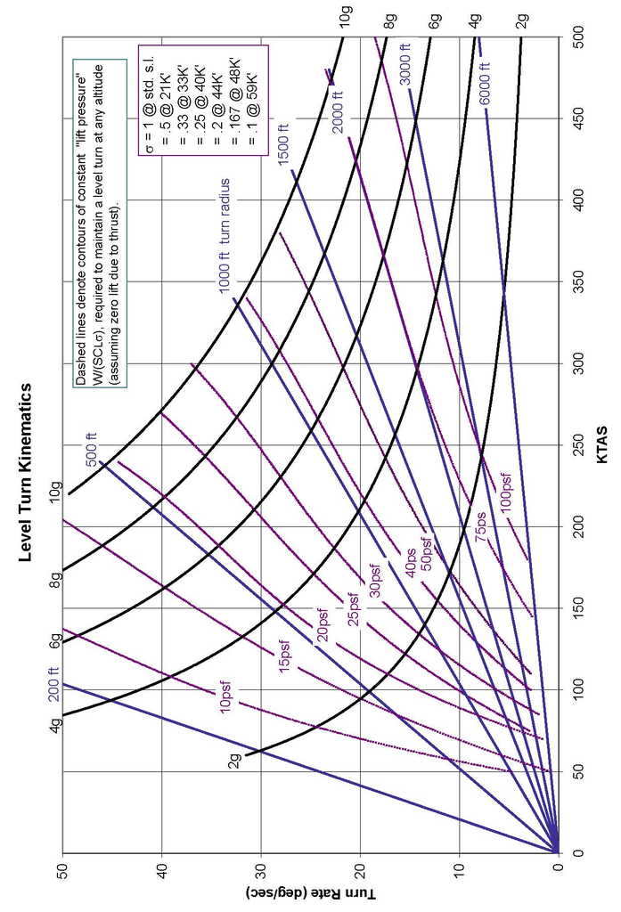

**Gyroscopic Motion**

(reference 1.7)

for bodies spinning about an axisymmetric axis

$\dot{\mathbf{\Psi}}$**=** spin rate

$\dot{\phi}$= precession rate

$\dot{\theta}$ = nutation rate

*I<sub>z</sub>* = moment of inertia about spin axis

*I<sub>t</sub>* = transverse moment of inertia about the spin point

(perpendicular to spin axis)

*I<sub>cg</sub>* = moment of inertia about the *cg* (perpendicular to spin axis)

M<sub>x</sub> = moment about spin point (acting along plane that defines θ)

**. .**

For steady precession (constant θ, φ , ψ )

$\sum_{}^{}M_{x} = - I_{t}\dot{\phi^{2}}\sin\theta\cos\theta + I_{z}\dot{\theta}\sin\theta\left( \dot{\phi}\cos\theta + \dot{\Psi} \right)$

For torque free motion (gravity is only external force)

$\dot{\Psi} = \frac{I_{\text{cg}} - I_{z}}{I_{z}}\dot{\phi}\cos$

note that *I<sub>cg</sub>>I<sub>z</sub>* yields regular precession

while *I<sub>cg</sub><I<sub>z</sub>* yields retrograde precession

**Section 1.9 International Phonetic Alphabet and Morse Code**

| A | Alpha | • ▬ |
| --- | --- | --- |
| B | Bravo | ▬●●● |
| C | Charlie | ▬ • ▬ • |
| D | Delta | ▬ • • |
| E | Echo | ● |
| F | Foxtrot | • • ▬ • |
| G | Golf | ▬ ▬ • |
| H | Hotel | • • • • |
| I | India | • • |
| J | Juliet | • ▬ ▬ ▬ |
| K | Kilo | ▬ • ▬ |
| L | Lima | • ▬ • • |
| M | Mike | ▬ ▬ |
| N | November | ▬ • |
| O | Oscar | ▬ ▬ ▬ |
| P | Papa | • ▬ ▬ • |
| Q | Quebec | ▬ ▬ • ▬ |
| R | Romeo | • ▬ • |
| S | Sierra | • • • |
| T | Tango | ▬ |
| U | Uniform | • • ▬ |
| V | Victor | • • • ▬ |
| W | Whiskey | • ▬ ▬ |
| X | X-ray | ▬ • • ▬ |
| Y | Yankee | ▬ • ▬ ▬ |
| Z | Zulu | ▬ ▬ • • |
| 1 | One | • ▬ ▬ ▬ |
| 2 | Two | • • ▬ ▬ ▬ |
| 3 | Three | • • • ▬ ▬ |
| 4 | Four | • • • • ▬ |
| 5 | Five | • • • • • |
| 6 | Six | ▬ • • • • |
| 7 | Seven | ▬ ▬ • • • |
| 8 | Eight | ▬ ▬ ▬ • • |
| 9 | Niner | ▬ ▬ ▬ ▬ • |
| 0 | Zero | ▬ ▬ ▬ ▬ ▬ |

**Section 1 References**

http://www.onlineconversion.com/

1.1 Anon., “Weight Engineers Handbook”, Society of Weight Engineers, P.O.Box 60024 Los Angeles, CA 90060,1976.

1.2 Anon., “Aeronautical Vestpocket Handbook”, United Technologies Pratt & Whitney Canada, 1000 Marie Victorin Blvd. E. P.O.B. 10 Longueuil, Quebec Canada J4K 4X9.

1.3 Jones, J. P., Hawkins, G.A., “Engineering Thermodynamics” John Wiley & Sons, 1960.

1.4 Esbach, Ovid W., “Handbook of Engineering Fundamentals”, John Wiley and Sons Inc., 1963.

1.5 Potter, M.C., Somerton, C.W., “Engineering Thermodynamics” Shaum’s Outline Series, McGraw-Hill, Inc.,1993.

1.6 Abbott, M. M., Van Ness, H. C., “Thermodynamics”, Shaum’s Outline Series, McGraw-Hill, Inc., 1989.

1.7 Halliday, D., Resnick, R., “Fundamentals of Physics”, John Wiley & Sons, New York, 1981.

1.8 Roberts, S.C., *Chapter 3 Aircraft Control Sytems* , “Aircraft Flying Qualities Testing”, National Test Pilot School, 1997. P.O.B. 658, Mojave, CA, 93501.

1.9 Unit Conversion Website Link http://www.digitaldutch.com/atmoscalc/.